# Ambientes

Noviembre, 2015

## Introducción

Consideremos por un momento cómo almacena sus archivos su computadora.

Cada archivo es almacenado en una carpeta, y cada carpeta es almacenada en otra carpeta, de manera que se forma un sistema de archivos jerárquicos.

[figure not shown]

R utiliza un sistema similar para almacenar los objetos. Cada objeto es almacenado dentro de un **ambiente**, como un objeto lista similar a las carpetas de su computador.

Cada ambiente está conectado a su ambiente padre, lo cual crea una jerarquía de ambientes.

## Trabajando con ambientes

R tienes múltiples funciones que ayudan a explorar sus ambientes.

- `as.enviroment()`: Toma el nombre de un ambiente y retorna información correspondiente al mismo.

```r
as.environment("package:stats")
```

```
#> <environment: package:stats>
#> attr(,"name")
#> [1] "package:stats"
#> attr(,"path")
#> [1] "/Library/Frameworks/R.framework/Versions/3.2/Resources/library/stats"
```

- `baseenv()`: Función de acceso al ambiente base (penúltimo ambiente). El ambiente base contiene las definiciones de un gran número de funciones primitivas.

```r
baseenv()
```

```
#> <environment: base>
```

## Trabajando con ambientes

- `globalenv()`: Función de acceso al ambiente global.

```r
globalenv()
```

```
#> <environment: R_GlobalEnv>
```

- `emptyenv()`: Función de acceso al ambiente vacío (último ambiente).

```r
emptyenv()
```

```
#> <environment: R_EmptyEnv>
```

- `parent.env()`: Permite buscar el padre de un ambiente.

```r
parent.env(globalenv())
```

```
#> <environment: package:hflights>
#> attr(,"name")
#> [1] "package:hflights"
#> attr(,"path")
#> [1] "/Library/Frameworks/R.framework/Versions/3.2/Resources/library/hflights"
```

## Trabajando con ambientes

- `environment()`: Muestra información del ambiente actual.

```r
environment()
```

```
#> <environment: R_GlobalEnv>
```

Notemos que el ambiente vacío es el único ambiente de R sin padre.

```r
parent.env(emptyenv())
```

```
#> Error in parent.env(emptyenv()): the empty environment has no parent
```

Para mirar los objetos almacenados dentro de un ambiente emplearemos las funciones: `ls()`, `ls.str()`. La primera función retorna únicamente el nombre de los objetos, mientras que la segunda función muestra información de la estructura de cada objeto.

```r
ls(baseenv())
```

```r
ls.str("package:datasets")
```

## Ambientes

Usaremos la siguiente metáfora para referir a la familia de ambientes: El abuelo de un ambiente es el padre de su padre, y los antecesores incluyen todos los ambientes padres hasta llegar al ambiente vacío.

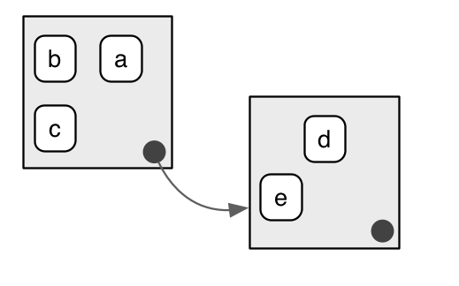

Cada ambiente tiene un padre que también es un ambiente. En el diagrama anterior se muestra como el puntero se direcciona al ambiente padre.

## Ambientes

Un ambiente es similar a un lista, con 4 importantes excepciones:

- Cada objeto en un ambiente tiene un nombre único.
- Los objetos en un ambiente no tienen orden, por lo cual no tiene sentido preguntar cuál es el primer objeto dentro del ambiente.
- Un ambiente tiene un padre.
- Los ambientes tienen referencias semánticas.

Para crear un ambiente de forma manual utilizamos la función `new.env()`.

```r
E <- new.env()
```

Por default el ambiente creado tiene como padre al ambiente global, sin embargo podemos asignarle un padre diferente del global mediante el argumento `parent`.

```r
D <- new.env(parent=emptyenv())
```

Para mostrar el padre de un ambiente emplearemos la función `parent.env()`.

```r
parent.env(D)
```

## Ambientes

Para modificar los enlaces dentro de un ambiente, trataremos estos como una lista:

```r
E$a <- 2
E$b <- c(1,2,3,4)
E$c <- FALSE
E$.d <- c(3,6,9)
E$.e <- "RStudio"
ls(E)
```

```
#> [1] "a" "b" "c"
```

La función `ls()` no muestra los nombres de los objetos que empiezan con `.`, sin embargo, disponemos de un argumento dentro de la misma función para mostrar todos los objetos del ambiente.

```r
ls(E, all.names = TRUE)
```

```
#> [1] ".d" ".e" "a"  "b"  "c"
```

## Ambientes

Otras funciones de interés para el manejo de ambientes son las siguientes:

- `get()`: Imprime un objeto de un ambiente, usa reglas de scoping para encontrar los objetos.

```r
get("a", envir=E)
```

```
#> [1] 2
```

- `exists()`: Comprueba la existencia de un objeto dentro de un ambiente o sus padres.

```r
exists("b", envir=E)
```

```
#> [1] TRUE
```

- `identical()`: Compara si dos ambientes son iguales.

```r
identical(emptyenv(), parent.env(D))
```

```
#> [1] TRUE
```

## Ejercicios

## Recursividad

Los ambientes son almacenados en forma de árboles, lo cual es conveniente para escribir funciones recursivas.

El factorial es una función recursiva, su implementación se muestra a continuación:

```r
factorial <- function(x){
      if(x==1){
            return(1)
      } else {
            return(x*factorial(x-1))
      }
}
```

```r
factorial(5)
```

```
#> [1] 120
```

```r
factorial(10)
```

```
#> [1] 3628800
```

## Recursividad

Revisemos un primer ejemplo de recursividad:

```r
where <- function(name, env = parent.frame()) {
  if (identical(env, emptyenv())) {
    # Caso Vacío
    stop("No se ha podido encontrar ", name, call. = FALSE)

  } else if (exists(name, envir = env, inherits = FALSE)) {
    # Caso exitoso
    env

  } else {
    # Caso recursivo
    where(name, parent.env(env))

  }
}
```

## Recursividad

Para la implementación de la función `where()` se consideraron lo siguientes casos:

- **Caso vacío**: Llegamos al ambiente vacío y no hemos encontrado el objeto. Dado que no podemos ir más lejos en la búsqueda, mostramos un error.
- **Caso existoso**: El objeto fue encontrado en el ambiente, por lo cual retornamos el ambiente.
- **Caso recursivo**: El objeto no fue encontrado en el ambiente actual, por tanto la búsqueda continúa en su padre.

## Recursividad

Revisemos los resultados de nuestra función `where()`.

```r
where("sum")
```

```
#> <environment: base>
```

```r
where("tbl_df")
```

```
#> <environment: package:dplyr>
#> attr(,"name")
#> [1] "package:dplyr"
#> attr(,"path")
#> [1] "/Library/Frameworks/R.framework/Versions/3.2/Resources/library/dplyr"
```

```r
where("plot")
```

```
#> <environment: package:graphics>
#> attr(,"name")
#> [1] "package:graphics"
#> attr(,"path")
#> [1] "/Library/Frameworks/R.framework/Versions/3.2/Resources/library/graphics"
```

## Ambientes de funciones

La mayoría de ambientes no son creadas por medio de la función `new.env()`, estos son creados como consecuencia del uso de funciones.

El ambiente **envolvente** es el ambiente donde la función fue creada. Cada función tiene uno y sólo un ambiente envolvente.

Cuando una función es creada, esta gana un referencia al ambiente dónde ésta fue construida. Podemos conocer el el ambiente envolvente de una función por medio de `environment()`.

```r
y <- 1
f <- function(x) x+y
environment(f)
```

```
#> <environment: R_GlobalEnv>
```

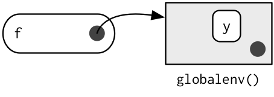

## Ambientes de funciones

```r
show_env <- function(){
      list(ran.in=environment(),
           parent=parent.env(environment()),
           objects=ls.str(environment()))
}
```

```r
show_env()
```

```
#> $ran.in
#> <environment: 0x7ff8f9280e00>
#>
#> $parent
#> <environment: R_GlobalEnv>
#>
#> $objects
```

## Ambientes de funciones

```r
show_env <- function(){
      a <- 1
      b <- 2
      c <- 3
      list(ran.in=environment(),
           parent=parent.env(environment()),
           objects=ls.str(environment()))
}
```

```r
show_env()
```

```
#> $ran.in
#> <environment: 0x7ff8fba00c30>
#>
#> $parent
#> <environment: R_GlobalEnv>
#>
#> $objects
#> a :  num 1
#> b :  num 2
#> c :  num 3
```

## Ambientes de ejecución

Qué retorna la siguiente función en la primera ejecución ? en la segunda ejecución ?.

```r
g <- function(x){
      if(!exists("a", inherits = FALSE)){
            message("Definiendo a")
            a <- 1
      } else {
            a <- a+1
      }
      a
}
```

```r
g(10)
```

```
#> Definiendo a
```

```
#> [1] 1
```

```r
g(10)
```

```
#> Definiendo a
```

```
#> [1] 1
```

## Preguntas